# Ford GoBike System Dataset Exploration

## by David Fakolujo

## Investigation Overview

My focus for this project were the relationships my main feature of interest (user_type) had with the gender and age supporting features.

## Dataset Overview

The dataset contained information of 183,412 individual rides made in a bike-sharing system in February 2019, covering the greater San Francisco Bay area.

## Distribution of User Types

Subscribers made about ten times more rentals than customers in February 2019, indicating that most of the people that regularly make use of the bike sharing system are subscribers

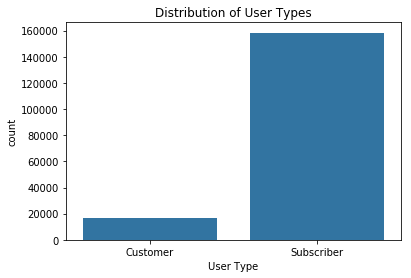

## Distribution of Member Genders

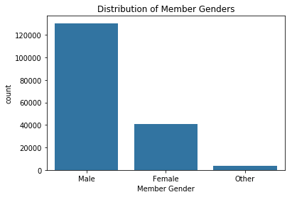

## Distribution of Age

Rentals made by people aged 80 and above were dropped to remove the unusual outliers. The distribution of the resulting data shows that most rentals were made by people in the age range of late twenties and early thirties

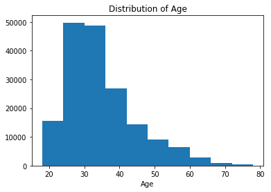

## User Type by Member Gender

There is a similar distribution of gender across the two user types. For both customers and subscribers, a higher number of rentals were made by males with a smaller number of rentals made by females, while rentals made by others were very little in comparison to the other genders. This shows that the user types had no effect on the distribution of genders in the data

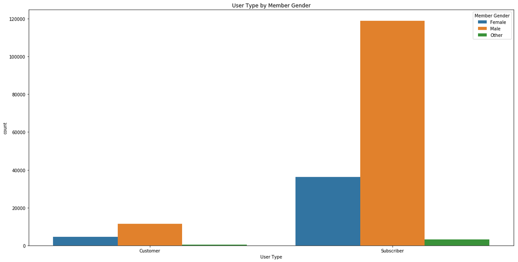

## Age against User Type

Identical to the gender distribution across user type, there was a similar distribution of ages across the two user types. The plot shows that for customers, most rentals were made by people aged 30, with a gradual decline upwards and downwards, while for subscribers, most rentals were made by indiviuals between mid twenties and early thirties. In addition, both categories had longer tails which show that a lot fewer rentals were made as ages increased.Both categories also have very similar quartiles.

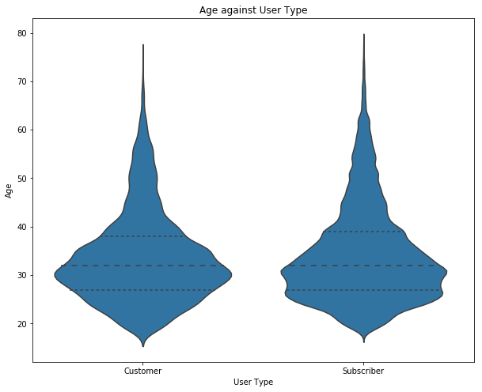

## Age against Member Gender

The boxplots show that females had the lowest median age that made rentals, followed by males which was slightly higher, while others had the highest median age, with all median ages being in the early thirties.

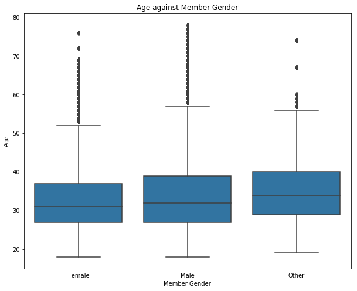

## Age against User Type, segmented by Member Gender

The boxplots show that for both user types, females had the lowest median age that made rentals, followed by males which was slightly higher, while others had the highest median age, with all median ages being in the early thirties. The females in both user types had similar quartiles, males in both user types also had similar quartiles; however, the other category had smaller quartiles in customers than in subscribers. Also, all genders across both customers and subsribers had outliers due to the drastic reduction in rentals as ages increased.

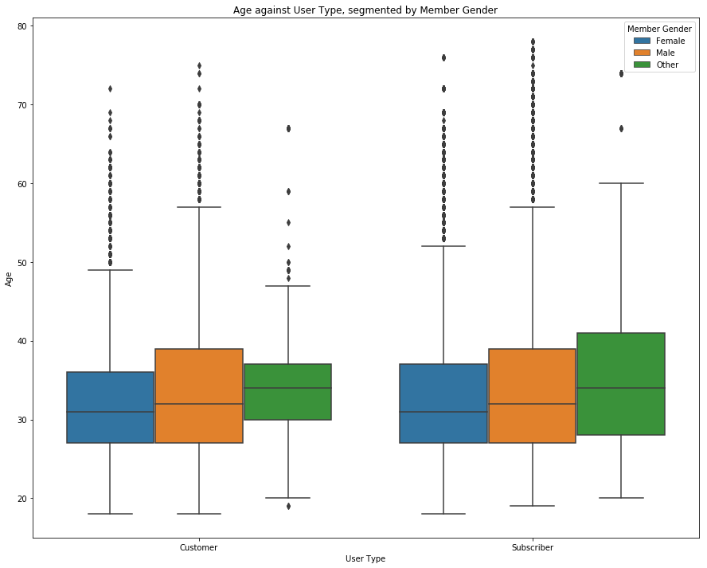